## Link with the American Community Survey (ACS)

First, you must download your “key” [here](http://api.census.gov/data/key_signup.html). They key is a 40 character string. In the background of this document, I have set my key to the variable acsKey.

The library acs will allow us to download data from R. The library choroplethr is super fancy for plotting.

```r
library(acs)
library(choroplethr)
api.key.install(key = acsKey)
```

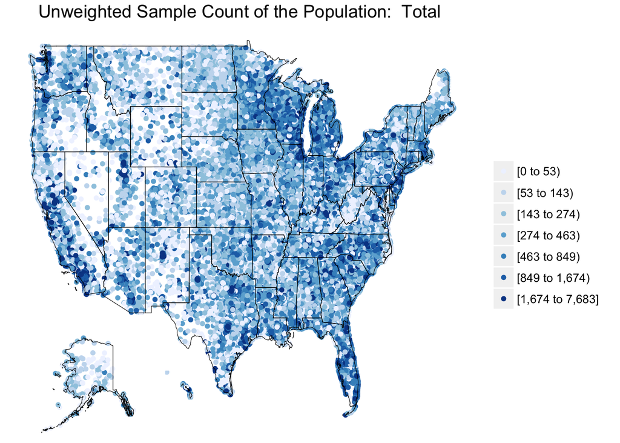

```r
choroplethr_acs(tableId="B00001", map = "zip")
```

To access the data, you need to define the geographic region of interest (with geo.make); here it is zip code, can also use counties, states, census tracts, etc. Then, you need to fetch the data (with acs.fetch). Make sure you are connected to the internet.

```r
us.zip=geo.make(zip.code = "*")
str(us.zip)
```

```
## Formal class 'geo.set' [package "acs"] with 3 slots
##   ..@ geo.list    :List of 1
##   .. ..$ :Formal class 'geo' [package "acs"] with 4 slots
##   .. .. .. ..@ api.for:List of 1
##   .. .. .. .. ..$ zip+code+tabulation+area: chr "*"
##   .. .. .. ..@ api.in : list()
##   .. .. .. ..@ name   : chr "Zip Code Tabulation Area *"
##   .. .. .. ..@ sumlev : num 860
##   ..@ combine     : logi FALSE
##   ..@ combine.term: chr "aggregate"
```

```r
us.transport=acs.fetch(geography=us.zip,
                         table.number="B08301", col.names="pretty")
str(us.transport)
```

```
## Formal class 'acs' [package "acs"] with 9 slots
##   ..@ endyear       : int 2011
##   ..@ span          : int 5
##   ..@ geography     :'data.frame':   33120 obs. of  2 variables:
##   .. ..$ NAME                 : chr [1:33120] "ZCTA5 01001" "ZCTA5 01002" "ZCTA5 01003" "ZCTA5 01005" ...
##   .. ..$ zipcodetabulationarea: chr [1:33120] "01001" "01002" "01003" "01005" ...
##   ..@ acs.colnames  : chr [1:21] "Means of Transportation to Work:  Total: " "Means of Transportation to Work:  Car, truck, or van: " "Means of Transportation to Work:  Car, truck, or van: Drove alone " "Means of Transportation to Work:  Car, truck, or van: Carpooled: " ...
##   ..@ modified      : logi TRUE
##   ..@ acs.units     : Factor w/ 5 levels "count","dollars",..: NA NA NA NA NA NA NA NA NA NA ...
##   ..@ currency.year : int 2011
##   ..@ estimate      : num [1:33120, 1:21] 8496 13774 4188 2718 7869 ...
##   .. ..- attr(*, "dimnames")=List of 2
##   .. .. ..$ : chr [1:33120] "ZCTA5 01001" "ZCTA5 01002" "ZCTA5 01003" "ZCTA5 01005" ...
##   .. .. ..$ : chr [1:21] "Means of Transportation to Work:  Total: " "Means of Transportation to Work:  Car, truck, or van: " "Means of Transportation to Work:  Car, truck, or van: Drove alone " "Means of Transportation to Work:  Car, truck, or van: Carpooled: " ...
##   ..@ standard.error: num [1:33120, 1:21] 321 614 457 134 236 ...
##   .. ..- attr(*, "dimnames")=List of 2
##   .. .. ..$ : chr [1:33120] "ZCTA5 01001" "ZCTA5 01002" "ZCTA5 01003" "ZCTA5 01005" ...
##   .. .. ..$ : chr [1:21] "Means of Transportation to Work:  Total: " "Means of Transportation to Work:  Car, truck, or van: " "Means of Transportation to Work:  Car, truck, or van: Drove alone " "Means of Transportation to Work:  Car, truck, or van: Carpooled: " ...
```

Notice that both of those previous objects are not standard R types. To get point estimates that are structured like a matrix (this is what we will typically want), use the function estimate.

```r
trans = estimate(us.transport) # get the data into a matrix.
is.matrix(trans)
```

```
## [1] TRUE
```

```r
str(trans)
```

```
##  num [1:33120, 1:21] 8496 13774 4188 2718 7869 ...
##  - attr(*, "dimnames")=List of 2
##   ..$ : chr [1:33120] "ZCTA5 01001" "ZCTA5 01002" "ZCTA5 01003" "ZCTA5 01005" ...
##   ..$ : chr [1:21] "Means of Transportation to Work:  Total: " "Means of Transportation to Work:  Car, truck, or van: " "Means of Transportation to Work:  Car, truck, or van: Drove alone " "Means of Transportation to Work:  Car, truck, or van: Carpooled: " ...
```

```r
dim(trans)
```

```
## [1] 33120    21
```

```r
head(trans)
```

```
##             Means of Transportation to Work:  Total:
## ZCTA5 01001                                      8496
## ZCTA5 01002                                     13774
## ZCTA5 01003                                      4188
## ZCTA5 01005                                      2718
## ZCTA5 01007                                      7869
## ZCTA5 01008                                       690
##             Means of Transportation to Work:  Car, truck, or van:
## ZCTA5 01001                                                   8112
## ZCTA5 01002                                                   8943
## ZCTA5 01003                                                   1034
## ZCTA5 01005                                                   2531
## ZCTA5 01007                                                   7119
## ZCTA5 01008                                                    660
##             Means of Transportation to Work:  Car, truck, or van: Drove alone
## ZCTA5 01001                                                               7585
## ZCTA5 01002                                                               7774
## ZCTA5 01003                                                                736
## ZCTA5 01005                                                               2106
## ZCTA5 01007                                                               6496
## ZCTA5 01008                                                                595
##             Means of Transportation to Work:  Car, truck, or van: Carpooled:
## ZCTA5 01001                                                               527
## ZCTA5 01002                                                              1169
## ZCTA5 01003                                                               298
## ZCTA5 01005                                                               425
## ZCTA5 01007                                                               623
## ZCTA5 01008                                                                65
##             Means of Transportation to Work:  Car, truck, or van: Carpooled: In 2-person carpool
## ZCTA5 01001                                                                                   344
## ZCTA5 01002                                                                                  1094
## ZCTA5 01003                                                                                   294
## ZCTA5 01005                                                                                   355
## ZCTA5 01007                                                                                   607
## ZCTA5 01008                                                                                    65
##             Means of Transportation to Work:  Car, truck, or van: Carpooled: In 3-person carpool
## ZCTA5 01001                                                                                   155
## ZCTA5 01002                                                                                    25
## ZCTA5 01003                                                                                     4
## ZCTA5 01005                                                                                    70
```

[output cut: 92 more lines]

```
## ZCTA5 01008                                         3
##             Means of Transportation to Work:  Other means
## ZCTA5 01001                                             27
## ZCTA5 01002                                             23
## ZCTA5 01003                                              0
## ZCTA5 01005                                              0
## ZCTA5 01007                                            101
## ZCTA5 01008                                              0
##             Means of Transportation to Work:  Worked at home
## ZCTA5 01001                                               143
## ZCTA5 01002                                              1587
## ZCTA5 01003                                              1260
## ZCTA5 01005                                               128
## ZCTA5 01007                                               523
## ZCTA5 01008                                                27
```

See [the data description here](https://www.socialexplorer.com/data/ACS2009_5yr/metadata/?ds=American+Community+Survey+Tables%3A++2005+--+2009+%285-Year+Estimates%29&table=B08006).

You can plot the data and see that it has a super long tail.

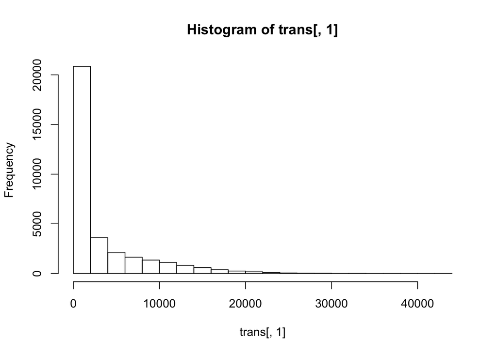

```r
trans = trans[,c(3,4,10,17,18,19)]
hist(trans[,1])
```

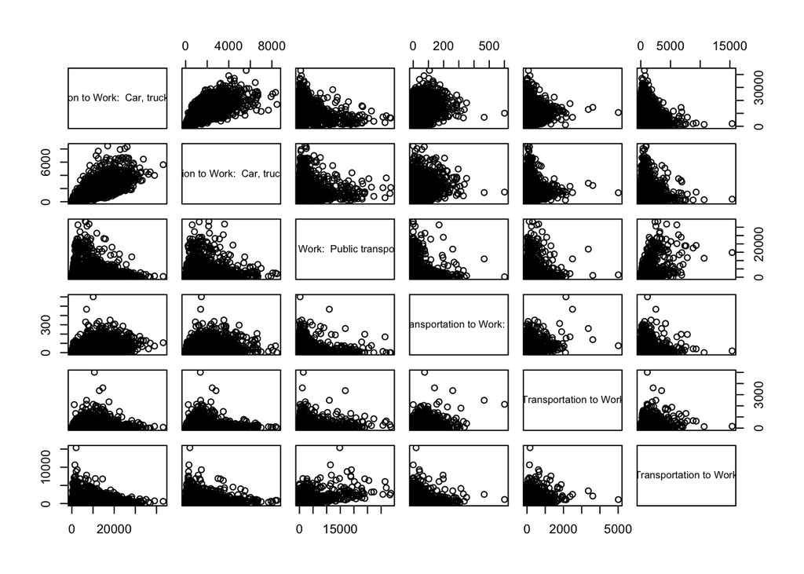

```r
# fat tails!
plot(as.data.frame(trans))  # tails make it hard to see patterns.
```

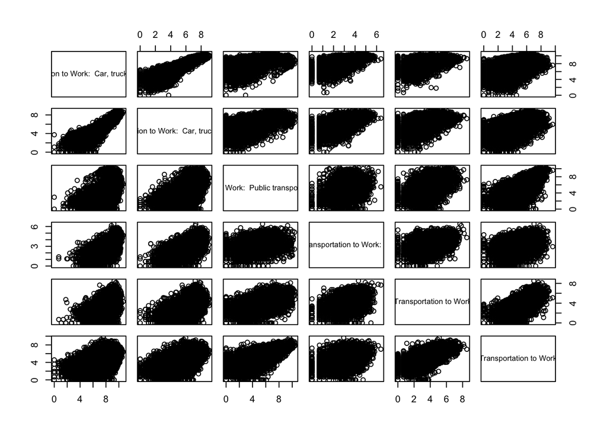

```r
# transform:
plot(as.data.frame(log(trans)))  # why is everything correlated?
```